# Final Report for Replication of Study 2 by Yang et al. (2018, Psychological Science)

Yuman Li (yumanl@stanford.edu)

December 15, 2019

## Introduction

### Justification for choice of experiment:

The study looks at children’s understanding of social norms in cooperation, specifically their evaluation and sanction of free riding phenomenon. The paper is closely related to my research interest in children’s social cognitive development. Most of my future work will be around social cognition & child studies, so I would prefer to do a replication on relevant topics.

### Description of Paper:

Across 6 studies, Yang et al.(2018) found that: children as young as 4 year olds negatively evaluate free riders, taking intention into consideration; children’s negative valuations towards free riders are not only determined by group impact caused by free riding or nonconformity to the majority; children treat free riders with punishment, but contributors with reward; the similar patterns continue to exist when switching to a situation in which children play as first-parties.

I aim to replicate study 2 for this paper, where the result suggested that 4 to 5-year-olds negatively evaluate free riders.

### Stimuli and procedures:

All the stimuli can be found on the OSF: https://osf.io/ke523/

Stimuli are pictures displayed on a laptop screen, along with the experimenter’s description of the story context. Participants were presented with two scenarios in which four members worked together in a group to achieve a common goal. If all four members contributed, the group could get a big reward; if only three of them contributed, the reward would only be a small one. The scenarios have two versions: free rider withholding resources vs. free rider withholding effort. In the former version, donating four chocolates to a piggybank won the group a bigger cake and donating plants into a garden produced more tomatoes. In the latter version, donation was replaced by cleaning the dirty piggybank and growing the tomatoes. Half of the children heared the donation version, and half of them heared the effort version. In terms of intention, each subject heard two scenarios, one involving a free-rider unwilling to contribute (intentional condition), one involving a free-rider willing but unable to contribute (unintentional condition).

The procedures were as below:

-Introduction about the game rules (Memory Check for Children’s Understanding of the rules)

-Free riding story - Scenario 1 (Intentional/Unintentional)

-Evaluation/Preference Questions (Contributor & Free rider)

-Free riding story - Scenario 2 (Unintentional/Intentional)

-Evaluation/Preference Questions (Contributor & Free rider)

### Anticipated Challenges:

1. Data collection with children will bring me much more work to do than using Amazon Mechanical Turk.
2. Need to connect to Bing Nursery School.

### Links:

Project Repository: https://github.com/psych251/yang2018

Original Paper: https://github.com/psych251/yang2018/tree/master/OriginalPaper

OSF Pre-registration: https://osf.io/3p4vt/

## Methods

### Power Analysis

I use the statistical test of “ANCOVA: Fixed effects, main effects and interactions” in G*Power to do power analysis. The original effect size is d = 1.62. To detect the effect size,

to achieve 80% power, N = 22; to achieve 90% power, N = 25; to achieve 95% power, N = 27.

### Planned Sample

Based on the power analysis and suggestions from the original author through email communication, the planned sample size will be 32 participants (4 to 5-year-olds) from Stanford Bing Nursery School.

### Materials

Materials below are quoted directly from original article:

“We presented each participant with two scenarios in which a four-member group could obtain a large reward if all four members contributed to a collective goal or a smaller reward if only three members contributed. The scenarios were described verbally by the experimenter and depicted through pictures on a laptop display. One scenario involved a magic piggy bank modeled after a public-goods game in which placing chocolates in a piggy bank would lead to the appearance of a cake that was then shared among the group. The other scenario involved a more naturalistic gardening setting in which placing plants in a garden produced tomatoes. Each participant heard both scenarios, one involving an unwilling free rider (intentional-free-riding condition) and one involving a willing but unable free rider (unintentional-free-riding condition). Key conditions and scenes are represented in Figure 1. To establish a modicum of generality, we investigated two types of free riding (withholding of a valuable resource versus withholding of effort). Half of the participants heard a donation version of the story (i.e., donate chocolate to the piggy bank and donate plants to the garden), and the other half of participants heard an effort version (i.e., clean the dirty piggy bank and grow the tomatoes). The type of free riding (withholding of resources versus effort) was thus manipulated between subjects, and across subjects, all pairings among scenario, type of free riding, and intentionality were included.”

Note: this will be followed precisely in the replication study.

### Procedure

The procedure below is quoted directly from original article:

“During testing, children were first introduced to the groups and told how the piggy bank or garden worked in terms of the rewards (i.e., get a bigger cake or basket of tomatoes with contributions from four members vs. three members). As a memory check, children were asked at the end of this familiarization phase about which reward the group would get if three versus four members contributed and all children answered the questions correctly. After familiarization, in the intentional-free-riding condition (Fig. 1a), children were shown through animations that the free rider kept the resources for themselves or made no actions. In the unintentional-free-riding condition (Fig. 1b), the free riders wanted to donate or make an effort to the group, but their resource was eaten by a pet (donation version) or they could not do the work because of an injury (effort version). In both conditions, the contributors put in the resources or made the actions. Finally, children were shown that the group got the second-best reward, and each child target got a small but equal share of the group reward. Children were asked to rate the free rider and one of the contributors on a 4-point scale indicating (a) how good or bad each character was (judgment question) and (b) how much they liked or disliked each character (preference question). At the end of the session, children were asked two memory questions about (a) whether the group received the bigger or the smaller reward (outcome question) and (b) whether three or four people contributed to the group (action question).”

Note: this will be followed precisely in the replication study.

### Analysis Plan

The procedure below is quoted directly from original article:

“All children answered the memory questions correctly. Children’s judgment and preference ratings ranged from 1 (most negative) to 4 (most positive). Preliminary results indicated no differences between the two types of scenario (piggy bank vs. gardening), the type of free riding (effort vs. donation), or the type of question (judgment vs. preference), so we collapsed across these factors in primary analyses. We used children’s judgment and preference ratings as indicators for evaluation ratings and analyzed data via mixed linear models predicting children’s ratings as a function of target (dummy coded; free rider vs. contributor), intentionality (dummy coded; whether the scenario involved intentional vs. unintentional free riding), child age, and the interactions among them, with a random intercept for participant. Data and code to replicate all analyses reported in this article are available at https://osf.io/g8xyt/.”

**Clarify key analysis of interest here**

Using a linear mixed regression model to test whether the identity of the target (free rider vs. contributor), intentionality, and interactions between these two variables predict children’s ratings.

### Differences from Original Study

1. The origianl study was conducted in a campus lab at Yale, at schools and at a local museum in New Haven, CT. But this study will be conducted at Stanford Nursery School in Palo Alto, CA, specifically in an ad hoc game room. Not sure whether there will be any differences between children from The East and West Coast of the United States in a big scope, but the change of specific rooms should be fine according to the author’s notes in the original paper.
2. The majority of children in the original studies were from middle-class families and of European American ethnicity (> 75%). Bing Nursery School, with a mission of providing a laboratory setting for research in developmental psychology, may have more diversified-background children in this aspect. I will check the children’s demographic information as I collect data.
3. Another difference is that I will run the experiment myself. The original study seemed to be run by several experimenters or research assistants. I have got the protocol from the original author, but minor differences will still be inevitable.

### Methods Addendum (Post Data Collection)

Since data collection with children is relatively slower, 17 children have participated in the study by the time of submitting this report. All the children reported here listened to the resource donation version of the story. I would consider keep running kids to reach my planned sample size 32 (maybe the rest of them using effort donation version of the story) after this course.

#### Actual Sample

My current sample size is 17, including 7 boys and 10 girls. The average age for them is 56.8 months (sample range: 49~70). Most of their racial backgrounds are Asians or Caucasians; 2 of them are African Americans. Subjects are from Stanford Bing Nursery School, mainly from two classes: WestAM and WestPM. I follow the exclusion rule from the original paper, which is excluding the child when he/she fails to correctly answer and does not change the answer for the memory check questions in the introduction phase. But in my study, most of the children answered the question correctly for the first time. For 3 to 4 children who did not get it right at first, they changed their answers after I explained the rule to them one or two more times.

#### Differences from pre-data collection methods plan

Only resource-donation version of the stories were told to children.

## Results

### Data preparation

Data preparation following the analysis plan.

```r
###Data Preparation

# required packages

####Load Relevant Libraries and Functions
library(tidyverse)   # 1.00
library(lme4)  # lmer / glmer  1.1-16
library(effsize) # cohens d calculator  0.7.1
library(optimx) # additional optimizers for glmer  2013.8.7

####Import data
repdata <- read.csv('FinalData.csv')

#### Data exclusion / filtering
#### Prepare data for analysis - create columns etc.

# convert to long format
longrepdata <- repdata %>%
  dplyr::select(SubID,AgeCentered,'Original_FR_Judgment':'Comparison_Con_Preference') %>%
  gather(condition,response,Original_FR_Judgment:Original_Con_Preference, Comparison_FR_Judgment:Comparison_Con_Preference) %>%
  mutate(intention=ifelse(substr(condition,1,2)=='Or','unwilling','unable')) %>%
  mutate (target=ifelse(grepl("FR",condition),"FreeRider","Contributor"))

# sanity check: check balance
table(longrepdata$intention,longrepdata$target)
```

```
##
##             Contributor FreeRider
##   unable             34        34
##   unwilling          34        34
```

```r
# fit maximal model
Mmax <- lmer(response ~ target*intention*AgeCentered + (1|SubID),data=longrepdata)
summary(Mmax)
```

```
## Linear mixed model fit by REML ['lmerMod']
## Formula: response ~ target * intention * AgeCentered + (1 | SubID)
##    Data: longrepdata
##
## REML criterion at convergence: 435.1
##
## Scaled residuals:
##     Min      1Q  Median      3Q     Max
## -1.9656 -0.7630  0.1886  0.6236  2.4583
##
## Random effects:
##  Groups   Name        Variance Std.Dev.
##  SubID    (Intercept) 0.2995   0.5473
##  Residual             1.1162   1.0565
## Number of obs: 136, groups:  SubID, 17
##
## Fixed effects:
##                                                Estimate Std. Error t value
## (Intercept)                                     3.38235    0.22460  15.059
## targetFreeRider                                -0.38235    0.25624  -1.492
## intentionunwilling                              0.02941    0.25624   0.115
## AgeCentered                                     0.03625    0.04773   0.760
## targetFreeRider:intentionunwilling             -0.76471    0.36238  -2.110
## targetFreeRider:AgeCentered                    -0.05750    0.05445  -1.056
## intentionunwilling:AgeCentered                 -0.06750    0.05445  -1.240
## targetFreeRider:intentionunwilling:AgeCentered  0.09086    0.07701   1.180
##
## Correlation of Fixed Effects:
##             (Intr) trgtFR intntn AgCntr trgFR: tFR:AC int:AC
## targetFrRdr -0.570
## intntnnwlln -0.570  0.500
## AgeCentered  0.000  0.000  0.000
## trgtFrRdr:n  0.403 -0.707 -0.707  0.000
## trgtFrRd:AC  0.000  0.000  0.000 -0.570  0.000
## intntnnw:AC  0.000  0.000  0.000 -0.570  0.000  0.500
## trgtFrR::AC  0.000  0.000  0.000  0.403  0.000 -0.707 -0.707
```

```r
drop1(Mmax, test='Chisq')
```

```
## Single term deletions
##
## Model:
## response ~ target * intention * AgeCentered + (1 | SubID)
##                              Df    AIC    LRT Pr(Chi)
## <none>                          432.11
## target:intention:AgeCentered  1 431.56 1.4571  0.2274
```

```r
# drop 3-way via LRT
M2way <- lmer(response ~ (target+intention+AgeCentered)^2 + (1|SubID),data=longrepdata)
summary(M2way)
```

```
## Linear mixed model fit by REML ['lmerMod']
## Formula: response ~ (target + intention + AgeCentered)^2 + (1 | SubID)
##    Data: longrepdata
##
## REML criterion at convergence: 433.2
##
## Scaled residuals:
##     Min      1Q  Median      3Q     Max
## -1.9408 -0.8091  0.1178  0.6392  2.4566
##
## Random effects:
##  Groups   Name        Variance Std.Dev.
##  SubID    (Intercept) 0.299    0.5468
##  Residual             1.120    1.0583
## Number of obs: 136, groups:  SubID, 17
##
## Fixed effects:
##                                    Estimate Std. Error t value
## (Intercept)                         3.38235    0.22479  15.047
## targetFreeRider                    -0.38235    0.25668  -1.490
## intentionunwilling                  0.02941    0.25668   0.115
## AgeCentered                         0.01354    0.04370   0.310
## targetFreeRider:intentionunwilling -0.76471    0.36300  -2.107
## targetFreeRider:AgeCentered        -0.01207    0.03857  -0.313
## intentionunwilling:AgeCentered     -0.02207    0.03857  -0.572
##
## Correlation of Fixed Effects:
##             (Intr) trgtFR intntn AgCntr trgFR: tFR:AC
## targetFrRdr -0.571
## intntnnwlln -0.571  0.500
## AgeCentered  0.000  0.000  0.000
## trgtFrRdr:n  0.404 -0.707 -0.707  0.000
## trgtFrRd:AC  0.000  0.000  0.000 -0.441  0.000
## intntnnw:AC  0.000  0.000  0.000 -0.441  0.000  0.000
```

```r
drop1(M2way, test='Chisq')
```

```
## Single term deletions
##
## Model:
## response ~ (target + intention + AgeCentered)^2 + (1 | SubID)
##                       Df    AIC    LRT Pr(Chi)
## <none>                   431.56
## target:intention       1 434.11 4.5446 0.03302 *
## target:AgeCentered     1 429.66 0.1022 0.74921
## intention:AgeCentered  1 429.90 0.3413 0.55907
## ---
## Signif. codes:  0 '***' 0.001 '**' 0.01 '*' 0.05 '.' 0.1 ' ' 1
```

```r
# drop target:age and intention:age
M2way2 <- lmer(response ~ target+intention+AgeCentered+target:intention+ (1|SubID),data=longrepdata)
summary(M2way2)
```

```
## Linear mixed model fit by REML ['lmerMod']
## Formula: response ~ target + intention + AgeCentered + target:intention +
##     (1 | SubID)
##    Data: longrepdata
##
## REML criterion at convergence: 424.3
##
## Scaled residuals:
##     Min      1Q  Median      3Q     Max
## -1.9576 -0.8642  0.1534  0.6330  2.4758
##
## Random effects:
##  Groups   Name        Variance Std.Dev.
##  SubID    (Intercept) 0.3009   0.5486
##  Residual             1.1048   1.0511
## Number of obs: 136, groups:  SubID, 17
##
## Fixed effects:
##                                     Estimate Std. Error t value
## (Intercept)                         3.382353   0.224046  15.097
## targetFreeRider                    -0.382353   0.254933  -1.500
## intentionunwilling                  0.029412   0.254933   0.115
## AgeCentered                        -0.003535   0.034149  -0.104
## targetFreeRider:intentionunwilling -0.764706   0.360529  -2.121
##
## Correlation of Fixed Effects:
##             (Intr) trgtFR intntn AgCntr
## targetFrRdr -0.569
## intntnnwlln -0.569  0.500
## AgeCentered  0.000  0.000  0.000
## trgtFrRdr:n  0.402 -0.707 -0.707  0.000
```

```r
drop1(M2way2, test='Chisq')
```

```
## Single term deletions
##
## Model:
## response ~ target + intention + AgeCentered + target:intention +
##     (1 | SubID)
##                  Df    AIC    LRT Pr(Chi)
## <none>              428.01
## AgeCentered       1 426.02 0.0121 0.91226
## target:intention  1 430.53 4.5280 0.03334 *
## ---
## Signif. codes:  0 '***' 0.001 '**' 0.01 '*' 0.05 '.' 0.1 ' ' 1
```

```r
# use above as final model
options(contrasts = c("contr.SAS", "contr.SAS'"))  # relevel contrasts to unintentional and contributor, respectively
repdatafinal<-lmer(response ~ target+intention+AgeCentered+target:intention+target:AgeCentered +(1|SubID),data=longrepdata)
summary(repdatafinal)
```

```
## Linear mixed model fit by REML ['lmerMod']
## Formula: response ~ target + intention + AgeCentered + target:intention +
##     target:AgeCentered + (1 | SubID)
##    Data: longrepdata
##
## REML criterion at convergence: 428.9
##
## Scaled residuals:
##     Min      1Q  Median      3Q     Max
## -1.9626 -0.8438  0.1454  0.6212  2.4642
##
## Random effects:
##  Groups   Name        Variance Std.Dev.
##  SubID    (Intercept) 0.2998   0.5476
##  Residual             1.1135   1.0552
## Number of obs: 136, groups:  SubID, 17
##
## Fixed effects:
##                                   Estimate Std. Error t value
## (Intercept)                        2.26471    0.22447  10.089
## targetContributor                  1.14706    0.25593   4.482
## intentionunable                    0.73529    0.25593   2.873
## AgeCentered                       -0.00957    0.03919  -0.244
## targetContributor:intentionunable -0.76471    0.36194  -2.113
## targetContributor:AgeCentered      0.01207    0.03846   0.314
##
## Correlation of Fixed Effects:
##             (Intr) trgtCn intntn AgCntr trgtC:
## trgtCntrbtr -0.570
## intentinnbl -0.570  0.500
## AgeCentered  0.000  0.000  0.000
## trgtCntrbt:  0.403 -0.707 -0.707  0.000
## trgtCntr:AC  0.000  0.000  0.000 -0.491  0.000
```

```r
confint(repdatafinal) # output confidence intervals
```

```
## Computing profile confidence intervals ...
```

```
##                                         2.5 %      97.5 %
## .sig01                             0.26777490  0.83185321
## .sigma                             0.91830243  1.18449684
## (Intercept)                        1.83489843  2.69451333
## targetContributor                  0.64994312  1.64417453
## intentionunable                    0.23817841  1.23240983
## AgeCentered                       -0.08504587  0.06590525
## targetContributor:intentionunable -1.46773366 -0.06167811
## targetContributor:AgeCentered     -0.06262639  0.08676701
```

```r
## Compute effect sizes: d for various simple contrasts
# output means of free riders vs contributors
longrepdata %>%
  group_by(target) %>%
  summarise(avg = mean(response))
```

```
## # A tibble: 2 x 2
##   target        avg
##   <chr>       <dbl>
## 1 Contributor  3.40
## 2 FreeRider    2.63
```

```r
# compute d
cohen.d(response ~ target, data=longrepdata)
```

```
##
## Cohen's d
##
## d estimate: 0.6420505 (medium)
## 95 percent confidence interval:
##     lower     upper
## 0.2942269 0.9898742
```

```r
# intentional vs unintentional free riders
longrepdata %>%
  filter(target=='FreeRider') %>%
  group_by(intention) %>%
  summarise(avg = mean(response))
```

```
## # A tibble: 2 x 2
##   intention   avg
##   <chr>     <dbl>
## 1 unable     3
## 2 unwilling  2.26
```

```r
# compute d
cohen.d(response ~ intention, data=filter(longrepdata,target=='FreeRider'))
```

```
##
## Cohen's d
##
## d estimate: 0.5955195 (medium)
## 95 percent confidence interval:
##     lower     upper
## 0.1006646 1.0903743
```

```r
# untintentional free riders vs contributors
longrepdata %>%
  filter(intention=='unable') %>%
  group_by(target) %>%
  summarise(avg = mean(response))
```

```
## # A tibble: 2 x 2
##   target        avg
##   <chr>       <dbl>
## 1 Contributor  3.38
## 2 FreeRider    3
```

```r
# compute d
cohen.d(response ~ target, data=filter(longrepdata,intention=='unable'))
```

```
##
## Cohen's d
##
## d estimate: 0.3429664 (small)
## 95 percent confidence interval:
##      lower      upper
## -0.1448185  0.8307514
```

```r
# NOTE: This includes a subset of figures only
library(scales)
# Graph
substrRight <- function(x, n){substr(x, nchar(x)-n+1, nchar(x))}
longrepdataGraph <- repdata %>%
  dplyr::select(SubID,'Original_FR_Judgment':'Comparison_Con_Preference') %>%
  gather(condition,response,Original_FR_Judgment:Original_Con_Preference, Comparison_FR_Judgment:Comparison_Con_Preference) %>%
  mutate(Ttype=substr(condition,1,2)) %>%
  mutate (Ctype=ifelse(grepl("FR",condition),"FreeRider","Contributor"))

longrepdataGraph$Ttype<-factor(longrepdataGraph$Ttype,levels=c("Or","Co"))#Change the order for Ttype
longrepdataGraph$Ctype<-factor(longrepdataGraph$Ctype,levels=c("FreeRider","Contributor"))#change the order for Ctype

reordergraph <- ggplot(longrepdataGraph,aes(x=Ctype, y = response, width=.65, fill = as.factor(Ttype))) +
  stat_summary(fun.y=mean, geom="bar", position=position_dodge()) +
  stat_summary(fun.data="mean_cl_boot", geom="errorbar",  aes(width=.15), position=position_dodge(.65))

graph<-(reordergraph +
           theme(legend.title=element_blank()) +
           scale_x_discrete(breaks=c("Contributor", "FreeRider"),labels=c("Contributor", "Free Rider")) +
           scale_y_continuous(limits=c(1,4),oob=squish,expand = c(0,0))+
           ylab("Rating (1 = most negative, 4 = most positive)") +
           xlab("Target") +
           theme_bw() + theme(panel.border = element_blank(), panel.grid.major = element_blank(), panel.grid.minor = element_blank(), axis.line = element_line(colour = "black"))+
           theme(legend.title=element_blank()) +
           scale_fill_manual(values=c("#99CC99", "#FFCC99"),breaks=c("Co", "Or"),labels=c("Unintentional Free-Riding", "Intentional Free-Riding")) +
           geom_hline(yintercept = 2.5, linetype=2, color='black')+
           guides(fill = guide_legend(reverse = TRUE))+ #reverse the legend order
           ggtitle("Replication: 4 to 5-year-olds") + theme(plot.title=element_text(hjust = "0", face="bold"))+
           theme(legend.position="top") +
           theme(legend.direction="horizontal")+
           theme(plot.title = element_text(size = 12, face = "bold") , legend.text=element_text(size=9))+
           theme(axis.text=element_text(size=10,face="bold"), axis.title=element_text(size=10,face="bold")))
```

### Confirmatory analysis

All the children answered the memory check questions correctly (4 of them were told more than once about the rule). I found the observed effects for target (beta = 1.15, 95% CI = [0.65,1.64]) and intentionality (beta = 0.74, 95% CI = [0.24,1.23]) and an interaction between target and intentionality (beta = -0.76, 95% CI = [-1.47,-0.06]). The effect for interaction between target and age found in the original paper was not found here.

In the replication study, 4 to 5-year-olds rated the contributors (M = 3.4) higher than the free riders (M = 2.63; d = 0.64) and rated unintentional free riders (M = 3) higher than intentional free riders (M = 2.26; d = 0.60). Both of these two are medium effect size.

Therefore, the replication of the main effects is successful.

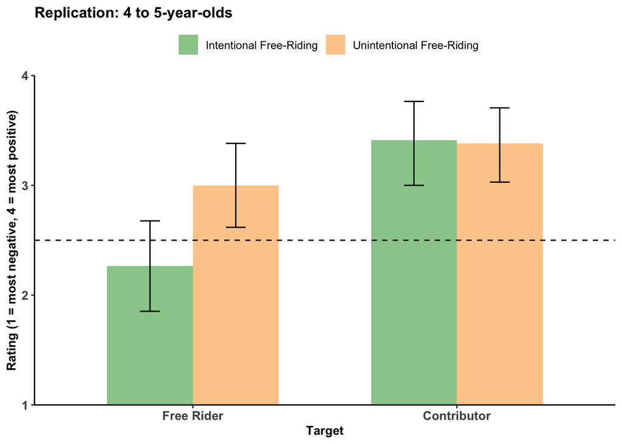

```r
graph
```

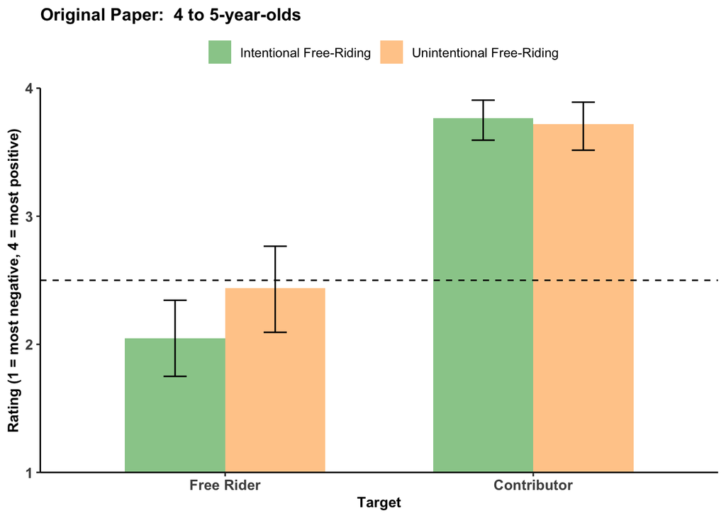

## Discussion

### Summary of Replication Attempt

Through my replication, I found the similar pattern of rating contributors higher than free riders and rating unintentional free riders higher than intentional free riders as in the original paper. Here are the differences I found: children in my replication study overall rated the contributors (M = 3.4) not as high as children in the original paper did (M = 3.74) and they did not rate the free riders (M = 2.63) as low as children in the original paper did (M = 2.24). That said, children in the replication study seems more generous or open-minded in judging whether the characters in stories are good or bad. This can be additionally supported by another piece of evidence from more ambiguous context that within free riders, for unintentional free riders, children in the original paper rated them more negatively than the neutral level. However, in my replication study, children rated unintentional free riders more positively than the neutral level.

### Commentary

1. The overall pattern in the replication study is consistent with that in the original paper.
2. The potential causes of the differences: 1.1 Current sample size is small (N = 17), so I need data from more subjects to come to a conclusion; 1.2 There are several children that may be the noises of the results. Instead of offering their answers based on the story contexts, 3 out of 17 children always gave the same ratings through out 8 questions, which may cause the ratings to be closer to the neutral level. Some children gave the completely opposite answers, rating free riders very high and rating contributors very low, which may become another cause.
3. Stimuli: the study uses faces of real children as stimuli. In my replication study, a number of children told me the reason of evaluating a character as “good” was because he/she looked good or like their brother/sister and the reason of evaluating a character as “bad” was because he/she was weird, which means that these children judged the characters based on their physical appearance instead of their behaviors in the story. The original paper did not mention the sources where these face stimili were from. I need to look into it. For future study, the faces might need to be first rated by a group of same-aged children to avoid biases if necessary.
4. Another interpretation for the differences occurring in the study following my intution is that it mighe be caused by west vs. east coast cultural differences. Maybe because the people that children in California get in touch with have more diversities, so they tend to be less likely to judge others with limited cues in an extreme way (particularly at Bing Nursery School where diversity is emphasized a lot). However, children from east coast may be more conventional.This could possibly become an interesting direction for future studies.